# Relatório de Análise dos Preços dos Combustíveis no Brasil (período compreendido entre 2014 e 2020)

Graciliano Márcio Santos Louredo

31/12/2021

## Introdução

O objetivo desta análise de dados é investigar a evolução histórica dos preços de combustíveis no Brasil, disponíveis nos dados abertos da Agência Nacional do Petróleo, Gás natural e Biocombustíveis (ANP) em [Preços de Combustíveis por Revenda](https://dados.gov.br/dataset/serie-historica-de-precos-de-combustiveis-por-revenda).

Neste conjunto de dados, foi escolhido o período de 2014 a 2020 para análise, a fim de considerar tendências anteriores e posteriores à penúltima alteração significativa na política de preços de combustíveis (em vigor desde julho/2017).

```r
library(sqldf) # Manipulação de dados com linguagem SQL
library(ggplot2) # Visualização gráfica
library(gridExtra) # Exibição de múltiplos gráficos na tela
library(tibble) # Visualização de tabelas
load('var-prep_cabr.RData') # Carga do conjunto de dados salvos e preparados
load('var-query_cabr.RData') # Carregamento das funções para consultas SQL
```

## Resultados da Análise

1. Qual o sumário estatístico descritivo (média, desvio padrão, máximo e mínimo) dos preços de venda de cada combustível em geral?

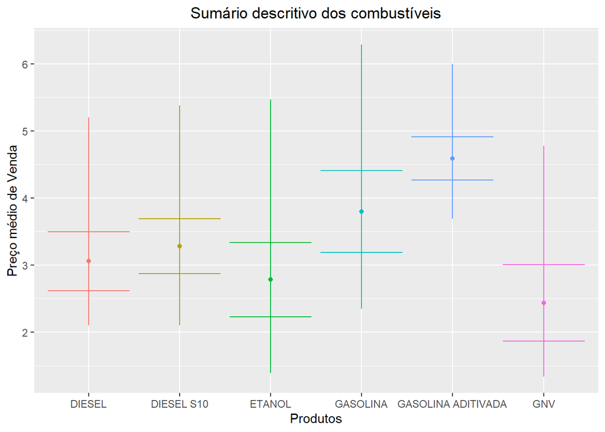

```r
Q1 <- SumEstCateg("Produto")

plt1 <- ggplot(Q1,aes(Q1$Produto, Q1$Media_Venda, colour=Q1$Produto)) +
  ggtitle("Sumário descritivo dos combustíveis") +
  theme(plot.title = element_text(hjust = 0.5)) +
  geom_point(aes(Q1$Produto, Q1$Media_Venda)) +
  geom_errorbar(aes(ymin = Q1$Media_Venda - Q1$DesvPad_Venda,
                    ymax = Q1$Media_Venda + Q1$DesvPad_Venda)) +
  geom_linerange(aes(ymin = Q1$Min_Venda, ymax = Q1$Max_Venda)) +
  xlab("Produtos") + ylab("Preço médio de Venda") +
  guides(color="none")
suppressWarnings(print(plt1))
```

A análise do comportamento dos preços por categoria de combustível revela que a variabilidade em torno da respectiva média, expressa pela faixa de erro central em cada categoria, foi relativamente parecida para todos os combustíveis. Por outro lado, a amplitude total da variação em todo o período pesquisado, dada pelo comprimento das linhas verticais, evidenciou uma oscilação maior de preços especialmente na **gasolina** e no **etanol**.

2. Qual a sumarização descritiva dos preços de venda do etanol, da gasolina e do diesel por ano?

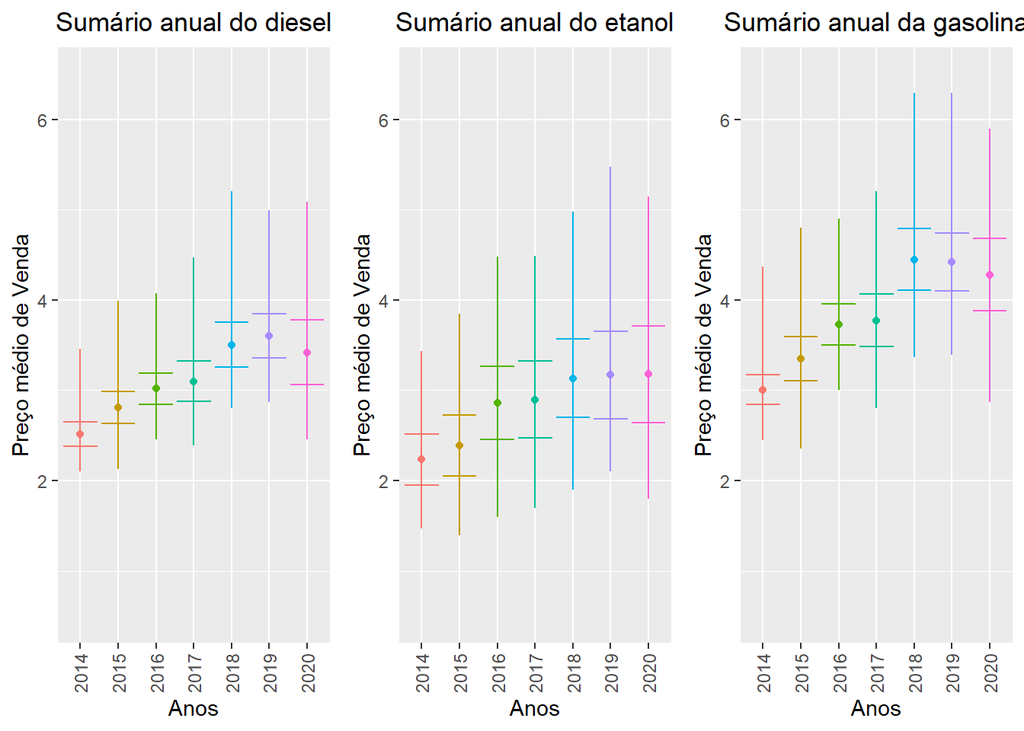

```r
Q2 <- SumEstCombAn(c("GASOLINA","DIESEL","ETANOL"))

Q2_1 <- Q2[1:7, ]
plt2 <- ggplot(Q2_1, aes(Q2_1$Ano_da_Coleta, Q2_1$Media_Venda,
                           colour = Q2_1$Ano_da_Coleta)) +
  ggtitle("Sumário anual do diesel") +
  theme(plot.title = element_text(hjust = 0.5)) +
  geom_point(aes(Q2_1$Ano_da_Coleta, Q2_1$Media_Venda)) +
  geom_errorbar(aes(ymin = Q2_1$Media_Venda - Q2_1$DesvPad_Venda,
                    ymax = Q2_1$Media_Venda + Q2_1$DesvPad_Venda)) +
  geom_linerange(aes(ymin = Q2_1$Min_Venda, ymax = Q2_1$Max_Venda)) +
  xlab("Anos") + ylab("Preço médio de Venda") + ylim(0.5,6.5) +
  theme(axis.text.x = element_text(angle = 90, vjust = 0.5, hjust=1)) +
  guides(color="none")
Q2_2 <- Q2[8:14, ]
plt3 <- ggplot(Q2_2, aes(Q2_2$Ano_da_Coleta, Q2_2$Media_Venda,
                           colour = Q2_2$Ano_da_Coleta)) +
  ggtitle("Sumário anual do etanol") +
  theme(plot.title = element_text(hjust = 0.5)) +
  geom_point(aes(Q2_2$Ano_da_Coleta, Q2_2$Media_Venda)) +
  geom_errorbar(aes(ymin = Q2_2$Media_Venda - Q2_2$DesvPad_Venda,
                    ymax = Q2_2$Media_Venda + Q2_2$DesvPad_Venda)) +
  geom_linerange(aes(ymin = Q2_2$Min_Venda, ymax = Q2_2$Max_Venda)) +
  xlab("Anos") + ylab("Preço médio de Venda") + ylim(0.5,6.5) +
  theme(axis.text.x = element_text(angle = 90, vjust = 0.5, hjust=1)) +
  guides(color="none")
Q2_3 <- Q2[15:21, ]
plt4 <- ggplot(Q2_3, aes(Q2_3$Ano_da_Coleta, Q2_3$Media_Venda,
                           colour = Q2_3$Ano_da_Coleta)) +
  ggtitle("Sumário anual da gasolina") +
  theme(plot.title = element_text(hjust = 0.5)) +
  geom_point(aes(Q2_3$Ano_da_Coleta, Q2_3$Media_Venda)) +
  geom_errorbar(aes(ymin = Q2_3$Media_Venda - Q2_3$DesvPad_Venda,
                    ymax = Q2_3$Media_Venda + Q2_3$DesvPad_Venda)) +
  geom_linerange(aes(ymin = Q2_3$Min_Venda, ymax = Q2_3$Max_Venda)) +
  xlab("Anos") + ylab("Preço médio de Venda") + ylim(0.5,6.5) +
  theme(axis.text.x = element_text(angle = 90, vjust = 0.5, hjust=1)) +
  guides(color="none")
suppressWarnings(print(grid.arrange(plt2, plt3, plt4, nrow = 1)))
```

O comparativo dos três combustíveis em questão mostra em geral uma tendência similar de aumento dos preços de venda (nominais) entre 2014 e 2019, com queda em 2020. Dentre eles, a **gasolina** teve uma variação de preços anual mais acentuada.

3. Para o combustível dentre os três anteriores com variação de preços mais acentuada em geral, qual região do país teve a maior taxa geral de aumento do preço de venda ao longo do período considerado?

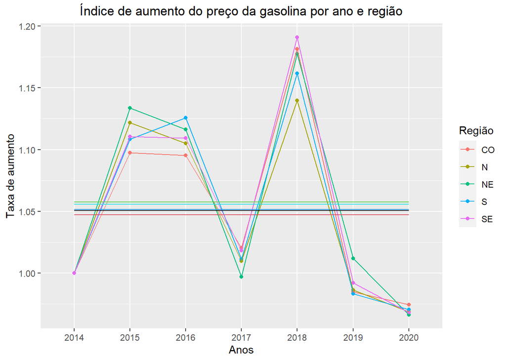

```r
Q3 <- TotAumComb("GASOLINA")

plt5 <- ggplot(Q3, aes(Q3$Ano_da_Coleta, Q3$Ind,
                    group = Q3$Regiao_Sigla, col = Q3$Regiao_Sigla)) +
        ggtitle("Índice de aumento do preço da gasolina por ano e região") +
        theme(plot.title = element_text(hjust = 0.5)) +
        geom_point(aes(Q3$Ano_da_Coleta, Q3$Ind)) +
        geom_line(aes(Q3$Ano_da_Coleta, Q3$Ind)) +
  geom_line(aes(Q3$Ano_da_Coleta,mean(Q3$Ind[Q3$Regiao_Sigla=="CO"])),color=1) +
  geom_line(aes(Q3$Ano_da_Coleta,mean(Q3$Ind[Q3$Regiao_Sigla=="N"])),color=2) +
  geom_line(aes(Q3$Ano_da_Coleta,mean(Q3$Ind[Q3$Regiao_Sigla=="NE"])),color=3) +
  geom_line(aes(Q3$Ano_da_Coleta,mean(Q3$Ind[Q3$Regiao_Sigla=="S"])),color=4) +
  geom_line(aes(Q3$Ano_da_Coleta,mean(Q3$Ind[Q3$Regiao_Sigla=="SE"])),color=5) +
        xlab("Anos") + ylab("Taxa de aumento") +
        scale_colour_discrete("Região")
suppressWarnings(print(plt5))
```

As linhas horizontais representam as médias dos índices de aumento dos preços de venda por região de cada ano em relação ao anterior entre 2014 e 2020. Dessa forma, observa-se que o **Nordeste** (NE) teve a maior taxa média de aumento anual do preço da gasolina no período considerado.

4. Para a região com maior taxa de aumento nos preços de venda do combustível, qual estado que teve a variação mais acentuada no preço médio de venda no período considerado?

```r
Q4 <- VarAcumReg("GASOLINA","NE")

tibble(`Estado` = Q4[ ,1], `Preço médio em 2014` = Q4[ ,2],
       `Preço médio em 2020` = Q4[ ,3], `Aumento acumulado` = Q4[ ,4])
```

| Estado | Preço médio em 2014 | Preço médio em 2020 | Aumento acumulado |
| --- | --- | --- | --- |
| AL | 3.004530 | 4.443842 | 1.4790 |
| BA | 3.027441 | 4.399968 | 1.4534 |
| CE | 3.051958 | 4.400334 | 1.4418 |
| MA | 3.023425 | 4.200474 | 1.3893 |
| PB | 2.871941 | 4.048231 | 1.4096 |
| PE | 2.947472 | 4.246877 | 1.4409 |
| PI | 2.859340 | 4.405739 | 1.5408 |
| RN | 3.024783 | 4.414670 | 1.4595 |
| SE | 2.952603 | 4.344502 | 1.4714 |

Ao observar a tabela acima, nota-se que o **Piauí** (PI) foi o estado nordestino com maior variação acumulada no preço da gasolina no período de 2014 a 2020.

5. Para o estado identificado no item anterior, quais foram os dois municípios com maior variação no preço de venda do combustível de modo geral em 2020?

```r
Q5 <- VarPrecEst("GASOLINA","PI","2020")

tibble(`Município` = Q5[ ,1], `Preço médio` = Q5[ ,2],
       `Desvio Padrão` = Q5[ ,3], `Coeficiente de Variação` = Q5[ ,4])
```

| Município | Preço médio | Desvio Padrão | Coeficiente de Variação |
| --- | --- | --- | --- |
| PICOS | 4.438 | 0.353 | 7.94 |
| PIRIPIRI | 4.441 | 0.319 | 7.18 |
| PARNAIBA | 4.519 | 0.303 | 6.71 |
| TERESINA | 4.369 | 0.258 | 5.90 |

6. Para os municípios identificados no item anterior, quais foram as duas principais bandeiras das distribuidoras de gasolina em percentual de participação?

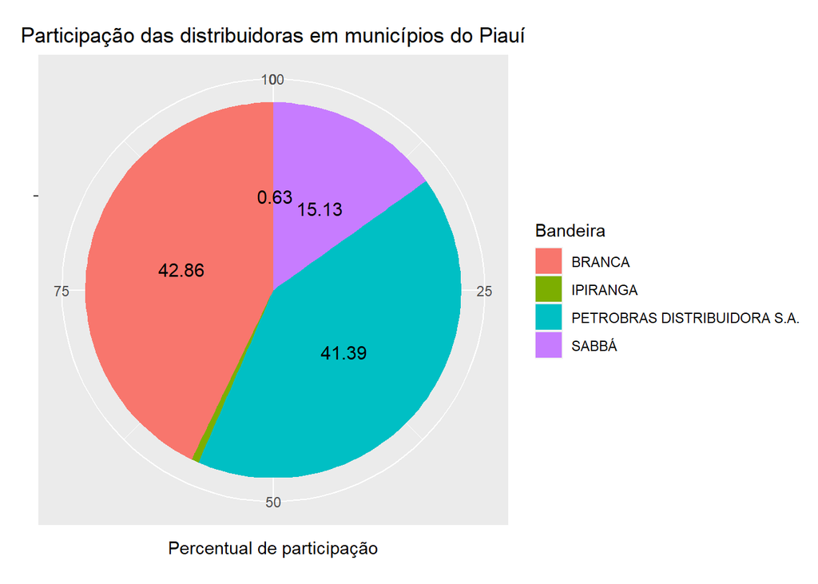

```r
Q6 <- TotPartBand("GASOLINA",c("PICOS","PIRIPIRI"),"2020")

plt6 <- ggplot(Q6, aes(x = "", y = Q6$Parte_bandeiras, fill = Q6$Bandeira)) +
    ggtitle("Participação das distribuidoras em municípios do Piauí") +
    theme(plot.title = element_text(hjust = 0.5)) +
    geom_bar(stat="identity", width=1) +
    coord_polar("y", start=0) +
    geom_text(aes(y = cumsum(Q6$Parte_bandeiras) - 0.5 * Q6$Parte_bandeiras, label = Q6$Parte_bandeiras),
        color = "black", size=4) +
    xlab("") +
    ylab("Percentual de participação") +
    scale_fill_discrete("Bandeira")
suppressWarnings(print(plt6))
```

De acordo com o gráfico de setores acima, pode-se afirmar que a bandeira com maior participação nos dois municípios piauienses é a **Petrobrás**. Embora os postos com **bandeira branca** tenham percentual de participação ligeiramente maior, eles podem receber combustíveis de qualquer distribuidora, inclusive da própria Petrobrás, já que não informam a marca.

## Conclusão

Diante dos resultados encontrados, é possível afirmar que algumas tendências passadas contribuíram em parte para o impacto sentido com o aumento recente dos preços dos combustíveis.

Em termos nacionais, os combustíveis com maior alta de preços registrada em 2021, segundo [Notícias G1](https://g1.globo.com/economia/noticia/2021/11/10/disparada-de-precos-etanol-e-gasolina-estao-entre-principais-altas-em-12-meses-veja-50-itens-que-mais-subiram.ghtml) e [Notícias Biodieselbr](https://www.biodieselbr.com/noticias/biocombustivel/negocio/gasolina-e-diesel-alcancam-maior-valor-real-em-20-anos-121121), já apresentavam oscilações maiores de preços entre 2014 e 2020. Além disso, a queda abrupta da atividade econômica em 2020 devido à pandemia de COVID-19, refletida na diminuição dos preços de venda dos combustíveis em geral, decerto fez com que os aumentos de preços em 2021 tivessem um impacto maior do que o normal, pelo fato de incidirem sobre uma base de preços menor.

Já em termos locais, pode-se constatar que territórios brasileiros com menor renda e maior desigualdade vem sentindo mais o impacto do aumento de preços desde o período de 2014 a 2020. No exemplo analisado, observa-se ainda que grandes distribuidoras dominam o mercado nesses lugares, de maneira que os preços praticados por elas tendem a influenciar bastante os preços de venda ao consumidor final.

Por fim, cabe enfatizar que conclusões mais aprofundadas somente serão possíveis mediante uma análise da série histórica de preços, a qual deve levar em conta um índice de correção monetária para comparação na mesma base. Tal indicador (geralmente um índice de preços ao consumidor) deve ser escolhido de forma a minimizar o viés existente pelo fato de incluir, na sua própria composição, um percentual da variação de preços dos combustíveis.